# MASTER UNIVERSITARI EN BIOINFORMÁTICA I BIOESTADÍSTICA

PAC1.Analisi de Dades Omiques.

Rai Puig Treserra

03 abril, 2025

DRAFT

**Resultats**

Dataset used in the CIMBC tutorial on “Basic Metabolomics Data Analysis Workflow” The tutorial describes the data as follows:

• The study used in this tutorial has been previously published as an open access article Chan et al. (2016), in the British Journal of Cancer.

• The deconvolved and annotated data file have been deposited at the Metabolomics Workbench data repository (Project ID PR000699).

• The data can be accessed directly via its project DOI:10.21228/M8B10B

• 1H-NMR spectra were acquired at Canada’s National High Field Nuclear Magnetic Resonance Centre (NANUC) using a 600 MHz Varian Inova spectrometer.

• Spectral deconvolution and metabolite annotation was performed using the Chenomx NMR Suite v7.6. Unfortunately, the Raw NMR data is unavailable.

```r
# Càrrega dels paquets:

library("dplyr")
library("readxl")
library("SummarizedExperiment")
```

```r
library("ggplot2")
library("pheatmap")  # Para mapas de calor
library("ggfortify") # Para PCA
library("tidyverse")
root5<-"C:/Users/Ramon/Desktop/UOC/2_SEMESTRE/AnàlisiDeDadesOmiques/PAC1/PAC1/dades/GastricCancer_NMR.xlsx"
```

# Exercici 1.

Seleccioneu i descarregueu un dataset de metabolòmica, que podeu obtenir de metabolomicsWorkbench o d ’aquest repositori de GitHub.

# Exercici 2.

Crea un objecte de classe SummarizedExperiment que contingui les dades i les metadades (informació sobre el dataset, les seves files i columnes). La classe SummarizedExperiment és una extensió d’ ExpressionSet, utilitzada per moltes aplicacions i bases de dades (com és el cas de 1 metabolomicsWorkbench). Quines són les seves principals diferències amb la classe ExpressionSet?

```
## class: SummarizedExperiment
## dim: 149 140
## metadata(0):
## assays(1): counts
## rownames(149): M1 M2 ... M148 M149
## rowData names(1): feature
## colnames(140): sample_1 sample_2 ... sample_139 sample_140
## colData names(4): Idx SampleID SampleType Class
```

```
## [1] 149 140
```

[output not shown]

[output cut: 85 more lines]

[output not shown]

```
## DataFrame with 6 rows and 4 columns
##                Idx    SampleID  SampleType       Class
##          <numeric> <character> <character> <character>
## sample_1         1    sample_1          QC          QC
## sample_2         2    sample_2      Sample          GC
## sample_3         3    sample_3      Sample          BN
## sample_4         4    sample_4      Sample          HE
## sample_5         5    sample_5      Sample          GC
## sample_6         6    sample_6      Sample          BN
```

```
## DataFrame with 6 rows and 1 column
##        feature
##    <character>
## M1          M1
## M2          M2
## M3          M3
## M4          M4
## M5          M5
## M6          M6
```

```
## SummarizedExperiment i ExpressionSet són dos tipos d’objectes d’R utilitzats per emmagatzemar dades òmiques.
```

```
##  Tot i que tenen funcionalitats similars, SummarizedExperiment és una versió més moderna i flexible que ha substituït en molts casos ExpressionSet.
```

```
## A continuació, es destaquen les seves diferències principals:
```

```
## Característica   SummarizedExperiment (SE)   ExpressionSet (ES)
```

```
## SE:Bioconductor (SummarizedExperiment)   ES:Bioconductor (Biobase)
```

```
## SE:Expressió génica, RNA-Seq, ChIP-Seq, proteòmica, metabolòmica ES:Principalment microarrays
```

```
## SE:Utilitza assays, rowData i colData    ES:Utilitza exprs, pData i fData
```

```
## SE:diverses matrius, ex. counts i TPM    ES:només una matriu principa
```

```
## SE:Més modular i compatible amb nous paquets ES:Més rígid i dissenyat per microarrays
```

```
## SE:Compatible amb GRanges per coordenades genòmiques ES:No té integració directa amb dades genòmiques
```

```
## SE:Optimitzat per grans volums de dades  ES:Més lent per a dades massives
```

# Exercici 3.

Porteu a terme una anàlisi exploratòria que us proporcioni una visió general del dataset en la línia del que hem vist en les activitats d’aquest repte.

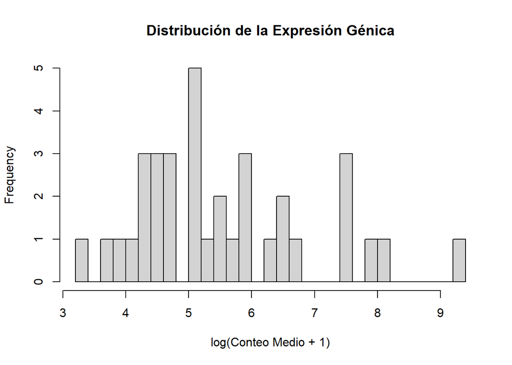

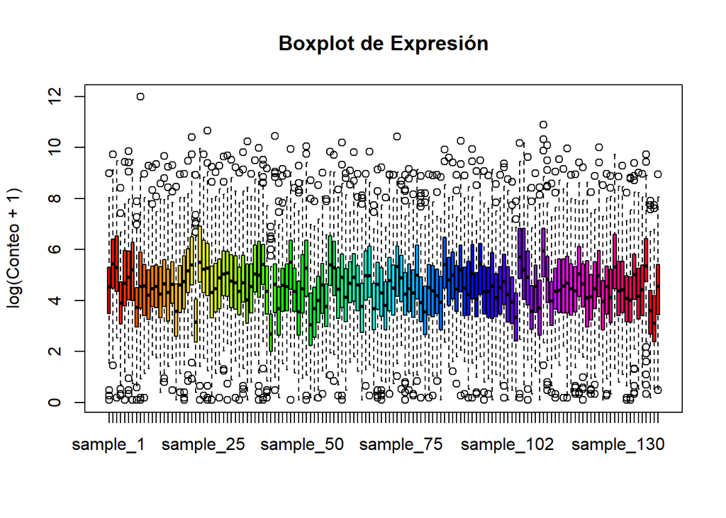

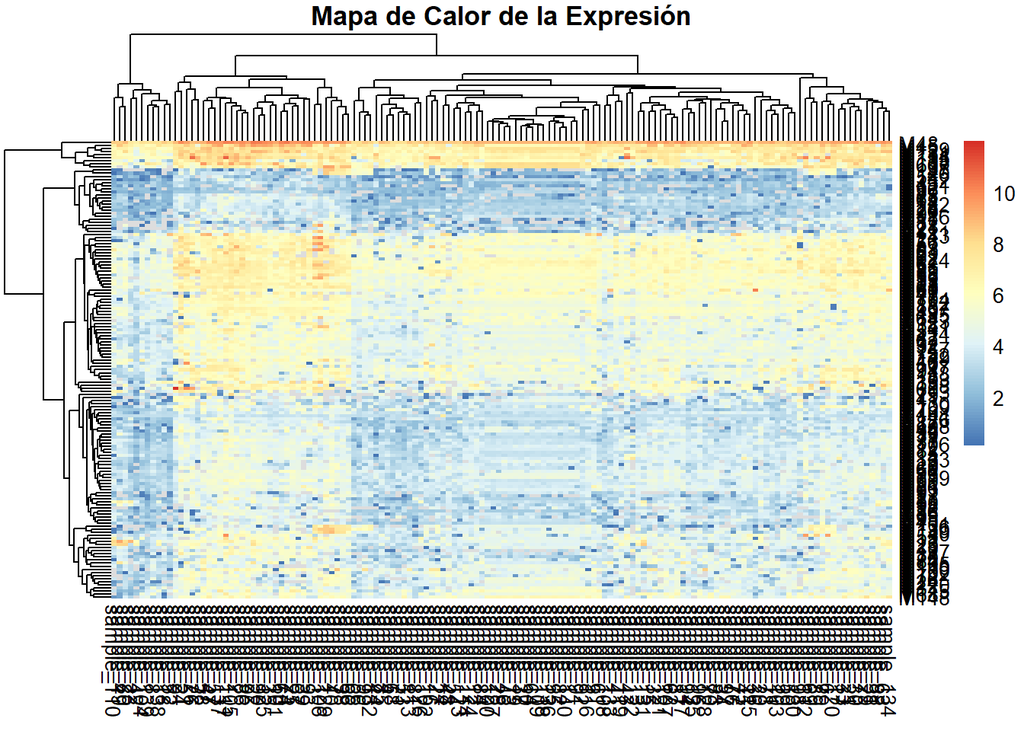

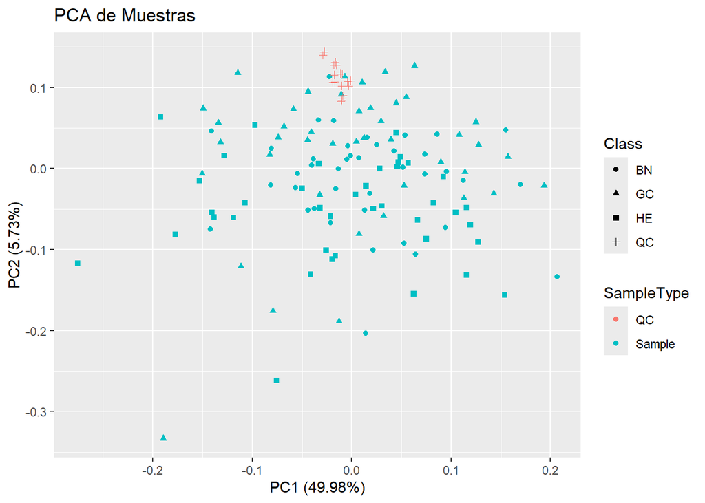

[output not shown]

# Exercici 4.

Elabora un informe que descrigui el procés que heu realitzat, incloent-hi la justificació de la selecció del dataset, la seva incorporació al summarizedExperiment, l’ anàlisi exploratòria de les dades i la interpretació dels resultats des del punt de vista biològic. L’extensió màxima d’aquest informe (sense tenir en compte els Annexos) ha de ser de 10 pàgines, en format PDF.

# Exercici 5.

Creau un repositori de GitHub que contingui:

1. l’ informe.
2. l’objecte de classe SummarizedExperiment que contingui les dades i les metadades en format binari (. Rda),
3. el codi R per a l’exploració de les dades degudament comentat (el control de versions del mateix s’ha de realitzar amb Git)
4. dades en format text i
5. les metadades acompanyades d’una breu descripció en un arxiu markdown.